# Supervised Learning

This is a data set with 2,000 sentences I pulled from the [Comparative Manifestos Project API](https://manifesto-project.wzb.eu/). These have been hand coded as either immigration related (or not). The code I used is [here](https://raw.githubusercontent.com/Neilblund/GVPT628-Fall2024/refs/heads/main/Week%2011/manifesto_api.R) (you’ll need a Manifesto Project API key to use it)

```r
library(tidyverse)
library(quanteda)
library(quanteda.textmodels)
library(caret)

immigr_sentences<-read_csv('https://raw.githubusercontent.com/Neilblund/APAN/refs/heads/main/immigration_sentences.csv')
```

# Text cleaning

We’ll start by cleaning the corpus and converting it to a DFM:

```r
immigr_corpus<-corpus(immigr_sentences$text, docvars=immigr_sentences|>select(-text))
immigr_tokens<-tokens(immigr_corpus,
                      what = 'word',
                      remove_punct =TRUE,
                      remove_symbols = TRUE,
                      remove_numbers = TRUE,
                      remove_url = TRUE,
                      remove_separators = TRUE,
                      include_docvars = TRUE
)|>
  tokens_wordstem()

immigr_dfm<-dfm(immigr_tokens)
```

And now we need to create a training and test set.

```r
ids<-seq(nrow(immigr_dfm))
set.seed(100)
train_ids<-sample(ids, size=round(length(ids) * .75))


dfmat_training <- dfm_subset(immigr_dfm, ids %in% train_ids)

# get test set
dfmat_test <- dfm_subset(immigr_dfm, !ids %in% train_ids)

# get matching features
dfmat_matched<-dfm_match(dfmat_test, features = featnames(dfmat_training))


tmod_nb <- textmodel_nb(dfmat_training,
                        docvars(dfmat_training, 'immigration_related'),
                        prior ='docfreq'
                        )
```

## Question 1

Get predictions for `dfmat_test` and create/assess the confusion matrix. How good is our classifier?

```r
# get the predictions for the test data
pred<-predict(tmod_nb, newdata=dfmat_matched)

# get the actual value of immigration related from the test data
actual<- docvars(dfmat_matched, "immigration_related")


# make a table with the predicted values in rows and the actual values in columns

tab<-table(pred, actual)

confusionMatrix(tab)
```

```
## Confusion Matrix and Statistics
##
##        actual
## pred    FALSE TRUE
##   FALSE   159   18
##   TRUE     83  240
##
##                Accuracy : 0.798
##                  95% CI : (0.7601, 0.8323)
##     No Information Rate : 0.516
##     P-Value [Acc > NIR] : < 2.2e-16
##
##                   Kappa : 0.5922
##
##  Mcnemar's Test P-Value : 1.912e-10
##
##             Sensitivity : 0.6570
##             Specificity : 0.9302
##          Pos Pred Value : 0.8983
##          Neg Pred Value : 0.7430
##              Prevalence : 0.4840
##          Detection Rate : 0.3180
##    Detection Prevalence : 0.3540
##       Balanced Accuracy : 0.7936
##
##        'Positive' Class : FALSE
##
```

We might want to compare this model to a model that uses a weighting scheme like TF-IDF to place more emphasis on more uncommon terms. We can create a weighted dfm using the `dfm_tfidf` function.

```r
weighted_immigr_dfm<-immigr_dfm|>
  dfm_tfidf()

wtd_dfmat_training <- dfm_subset(weighted_immigr_dfm, ids %in% train_ids)
# get test set
wtd_dfmat_test <- dfm_subset(weighted_immigr_dfm, !ids %in% train_ids)

# get matching features
wtd_dfmat_matched<-dfm_match(wtd_dfmat_test, features = featnames(wtd_dfmat_training))


wtd_tmod_nb <- textmodel_nb(wtd_dfmat_training,
                        docvars(dfmat_training, 'immigration_related'),
                        prior ='docfreq'
                        )

wtd_tmod_lr <- textmodel_lr(wtd_dfmat_training,
                        docvars(wtd_dfmat_training, 'immigration_related')
                        )
```

## Question 2

Compare `wtd_tmod_nb`, `wtd_tmod_lr` and `tmod_nb`. Does one perform significantly better than the others?

```r
actual<-docvars(dfmat_matched, "immigration_related")


nb_tab<- predict(tmod_nb, newdata=dfmat_matched) # prediction from naive bayes

wtd_nb_tab <- predict(wtd_tmod_nb, wtd_dfmat_matched) # prediction from naive bayes with tf_idf

wtd_lr_tab <- predict(wtd_tmod_lr, wtd_dfmat_matched) # prediction from weighted elastic net regression


# make a confusion matrix for each model
c1<-confusionMatrix(table(nb_tab, actual))
c2<-confusionMatrix(table(wtd_nb_tab, actual))
c3<-confusionMatrix(table(wtd_lr_tab, actual))


# compare the overall metrics across each one:
data.frame(
  'Naive Bayes' =c1$overall,
  'Tf-IDF Naive Bayes' =c2$overall,
  'Elastic Net' =c3$overall)
```

|  | Naive.Bayes | Tf.IDF.Naive.Bayes | Elastic.Net |
| --- | --- | --- | --- |
| Accuracy | 7.980000e-01 | 8.060000e-01 | 8.160000e-01 |
| Kappa | 5.921894e-01 | 6.088457e-01 | 6.348047e-01 |
| AccuracyLower | 7.600903e-01 | 7.685699e-01 | 7.792009e-01 |
| AccuracyUpper | 8.323421e-01 | 8.397648e-01 | 8.490113e-01 |
| AccuracyNull | 5.160000e-01 | 5.160000e-01 | 5.160000e-01 |
| AccuracyPValue | 3.629290e-39 | 1.736886e-41 | 1.641724e-44 |
| McnemarPValue | 1.912120e-10 | 4.184822e-08 | 2.843839e-12 |

# K-fold cross validation

Using a hold-out set can help reduce the risk of overfitting, but its still possible to overfit to our held-out set. Rather than using a single test set, we might be better off dividing the data into “K” equally sized groups, running the model K times, and then averaging our metrics across all of them.

The `caret` package provides a great set of tools for k-fold cross validation, but we’re going to try to set this up manually for this problem.

```r
generateFolds<-function(ids, k=10, seed=NULL){
  if(!is.null(seed)){
    set.seed(seed)
  }
  # shuffle ids
  folds<-setNames(split(ids, cut(sample(length(ids)), k)), 1:k)
  # train ids instead of test ids
  fold_ids<-lapply(folds, function(x) ids[!ids%in%x])
  return(fold_ids)
}

ids<- seq(nrow(immigr_dfm))

folds<-generateFolds(ids=ids, k=10, seed=999)
```

## Question 3

Write a loop to iterate over each fold, train a model on the training set, predict the hold-out set, and then store the results of the `overall` metrics from using the confusionMatrix function on the result.

```r
# make the IDs
ids<- seq(nrow(immigr_dfm))


# generate 40 folds
folds<-generateFolds(ids=ids, k=40, seed=999)

# make an empty data frame
metrics_df<-data.frame()


for(i in 1:length(folds)){
  # get the train ids from fold i
  train_ids<-folds[[i]]

  dfmat_training <- dfm_subset(immigr_dfm, ids %in% train_ids)

  # get test set
  dfmat_test <- dfm_subset(immigr_dfm, !ids %in% train_ids)

  # get matching features
  dfmat_matched<-dfm_match(dfmat_test, features = featnames(dfmat_training))


  tmod_nb <- textmodel_nb(dfmat_training,
                        docvars(dfmat_training, 'immigration_related'),
                        prior ='docfreq'
                        )

  pred<-predict(tmod_nb, newdata=dfmat_matched)

  # get the actual value of immigration related from the test data
  actual<- docvars(dfmat_matched, "immigration_related")


  # make a table with the predicted values in rows and the actual values in columns

  tab<-table(pred, actual)

  # run the confusionMatrix and just get the overall scores from the output
  result<-confusionMatrix(tab)$overall
  # add the result to the data frame
  metrics_df<-bind_rows(metrics_df, result)


}



colMeans(metrics_df)
```

```
##       Accuracy          Kappa  AccuracyLower  AccuracyUpper   AccuracyNull
##     0.78000000     0.55489446     0.64151572     0.88349708     0.56700000
## AccuracyPValue  McnemarPValue
##     0.03012539     0.18063518
```

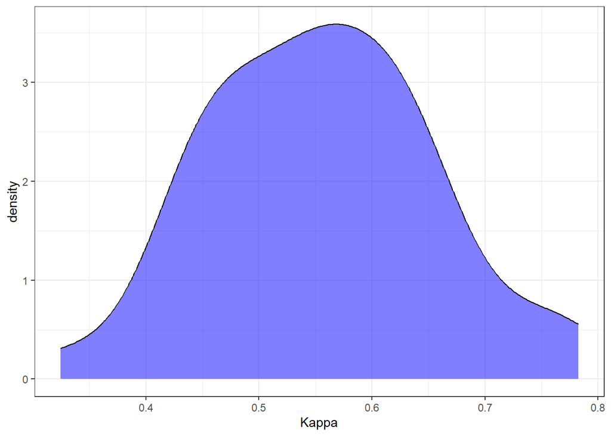

```r
ggplot(metrics_df, aes(x=Kappa)) + geom_density(fill='blue', alpha=.5) +
  theme_bw()
```